# Erben in Wien - Einsichten aus Verlassenschaftsakten

27.2.2023

## Hintergrund

## Überblick

- Problem: Bessere Datenbasis zu Erbschaften erforderlich
- Vorschlag: Zusammenstellen und deskriptive Auswertung eines neuen Datensatzes zu Erbschaften in Wien
- Idee: Erschließung der Verlassenschaftsakten in Wiener Bezirksgerichten, die den Übergang des Eigentums von Erblasser/-innen auf Erb/-innen dokumentieren.

## Motivation I

Erbschaften sind von großer Bedeutung für zentrale ökonomische Prozesse. Das umfasst zum Beispiel:

- Arbeitsangebot
- Vermögensakkumulation und -verteilung
- Soziale Mobilität
- Öffentliche Finanzen

## Motivation II

Aber: Empirische Evidenz zum Erben in Österreich und Wien stark limitiert.

- Seit Abschaffung der Erbschafts- und Vermögenssteuer (2008, 1993) keine Steuerdaten verfügbar
- Ummfragen zu Erbschaften: Household Finance and Consumption Survey (alle 3 Jahre, retrospektive Fragen zu Erbschaften)
  - Umfragen bringen unterschiedliche Verzerrungen mit sich (v.a. beim Erben): bis zu 80 Prozent Unterschätzung des Erbvolumens
  - Geringe Fallzahlen machen regional fokussierte Auswertung statistisch unzuverlässig

## Verlassenschaftsverfahren

## Verlassenschaften

- Österreichisches Erbrecht sieht vor, dass Vermögen von Erblasser/-innen nicht automatisch in Eigentum der erbberechtigten Personen übergeht: Vermögen bekommt eine Rechtsperson (“Verlassenschaft”)
  - Verlassenschaftsverfahren zur Übertragung von Eigentum
  - Durchgeführt von Notar/-innen (Gerichtskommissär/-innen)
- Im Verlassenschaftsverfahren wird das Vermögen der Verstorbenen Person ermittelt
- Die Verfahrensschritte und Erkenntnisse werden in einem Akt dokumentiert und im zuständigen Bezirksgericht archiviert
- Akten unterliegen strenger Geheimhaltung. Es gibt eine Ausnahme für wissenschaftliche Zwecke - §219(4) ZPO

## Prozedere

- In jedem Todesfall kommt es zu einer Todesfallaufnahme, meist im Rahmen eines Termins der Angehörigen bei einem zugewiesenen Notariatsbüros
  - Feststellung der Zuständigkeit der österr. Gerichte
  - Zusammentragen wesentlicher Informationen zu gesetzlichen Erb/-innen und Personen, die durch Testamente/Vermächtnisse begünstigt werden
  - Wichtige Vorkehrungen: Bezüge aus öffentlichen Kassen, Schusswaffen
  - Einholen von Infos zu Aktiva/Passiva
- Entscheidung über Einleitung eines Verlassenschaftsverfahrens

## Verfahrensarten

- Bedingte oder ubedingte Erbantrittserklärung (Errichtung Inventar/Vermögenserklärung)
- Unterbleiben der Abhandlung (Aktiva unter 4000 EUR, keine Eintragung in öffentliche Bücher)
- Überschuldet
  - Verlassenschaftsinsolvenzverfahren
  - Überlassung an Zahlungs statt: Überlassung der Aktiva an Gläubiger/-innen (wenn weder Erbantrittserklärung, Verlassenschaftsinsolvenzverfahren oder erblose Überlassung vorliegt)

## Informationsgehalt der Akten

- Demografische Informationen (Datum Geburt/Tod, Geburtsort, Nationalität, Geschlecht, Familienstand)
- Testierverhalten (Testament J/N, Legate J/N)
- Wohnform
- Art des Verlassenschaftsverfahrens
- Erb/-innengemeinschaft
- Vermögen (insb. Bankeinlagen, Sparbücher, Bausparer, Depots und Wertpapiere, Immo, Fahrzeuge, Bargeld, Wertgegenstände und Pretitiosen, Versicherungen)
- Schulden (Bankschulden und Kredite, Pflege, Steuern)

## Stichprobe

## Vorgehensweise

- ✔️ Pilotprojekt
- ✔️ Auswahl der Bezirksgerichte basierend auf Abdeckung der Bevölkerung und Durchschnittsvermögen
- ✔️ Einholung der Einsichtsbewilligung vom BMJ: bereits gewährt
- ✔️ Ziehung einer Stichprobe aus der Population der Verlassenschaftsakten 2014-2019 und Bereitstellung der Aktenzahlen durch das BRZ:
  - 95% basierend auf zufälliger Stichprobe
  - 5% der Akten mit den meisten Verfahrensschritten je Bezirk
- Spezifische Arrangements mit den betrefflichen BGs für die Einsichtsmodalitäten

## Abdeckung

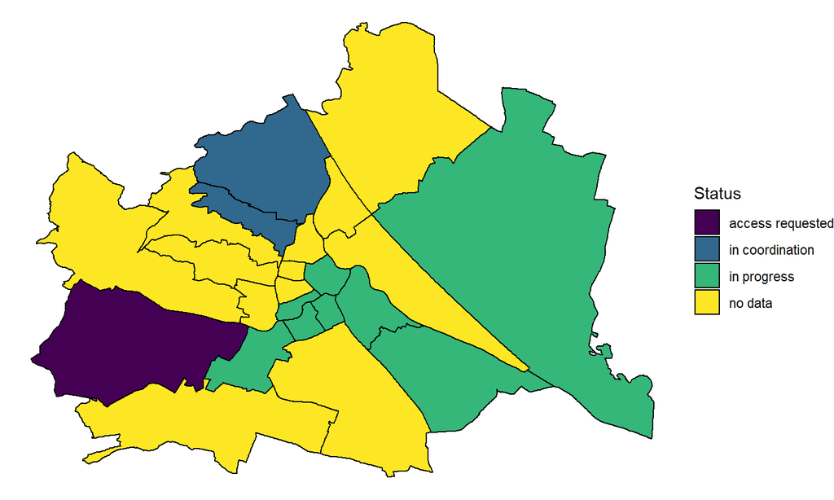

## Die Bezirke

| Gerichtsbezirk | Nettovermögen | Verstorbene | Stichprobe |
| --- | --- | --- | --- |
| Innere Stadt | 180342.3 | 2776.3 | 3834 |
| Josefstadt | 159016.3 | 753.0 | 0 |
| Favoriten | 119046.1 | 1730.7 | 0 |
| Meidling | 152630.3 | 932.7 | 300 |
| Hietzing | 343656.9 | 697.3 | 516 |
| Rudolfsheim-Fünfhaus | 104823.7 | 1487.7 | 0 |
| Hernals | 147336.2 | 1267.7 | 0 |
| Döbling | 259887.3 | 1344.3 | 1098 |
| Floridsdorf | 122849.3 | 1323.3 | 0 |
| Donaustadt | 134857.2 | 1270.0 | 1158 |
| Liesing | 201922.2 | 956.0 | 0 |
| Leopoldstadt | 95913.2 | 1692.7 | 0 |

<sup>a</sup> Nettovermögen und Verstorbene bezieht sich auf Durchschnitte über mehrere Jahre

## Organisatorisches

## Schedule

|  | Sampling | Datenbereinigung | Auswertung | Projektbericht |
| --- | --- | --- | --- | --- |
| März | x |  |  |  |
| April | x |  |  |  |
| Mai | x |  |  |  |
| Juni | x |  |  |  |
| Juli |  | x |  |  |
| August |  | x |  |  |
| September |  | x | x |  |
| Oktober |  |  | x |  |
| November |  |  | x | x |
| Dezember |  |  |  | x |
| Jänner |  |  |  | x |